# NW PLN

# Setup

### Sites

| year | method | number of sites |
| --- | --- | --- |
| 2019 | camera + remains | 6 |
| 2019 | remains only | 6 |
| 2020 | camera + remains | 8 |

(But remember that the number of remains-only sites is still incomplete.)

**Should I be switching back to a site-based (vs nest-based) approach for at least some things?** This avoids double-counting sites that are used in both years and is necessary for occupancy anyway.

### Scale

| size | area | radius |
| --- | --- | --- |
| PFA | 60.00 | 437.0194 |
| breeding area | 175.00 | 746.3527 |
| breeding home range | 3800.00 | 3477.8982 |
| maximum range | 32902.97 | 10233.9342 |

#### **Where do these numbers come from?**

McClaren et al. (2005) uses 95% adaptive kernel estimates from 12 fledglings at 12 different nests over 2 years (6 per year) to estimate the PFA size on Vancouver Island to be **59.2** +/- 16.1 **ha** (which I round to 60 ha).

McClaren et al. (2015) generated PFA-sized buffers around known nests and calculted the total area covered within each territory to get a 90th percentile estimate of **175.2 ha** (which I round to 175 ha).

McClaren et al. (2015) gives the size of the breeding season home range to be 3700 ha on Vancouver Island in one location and as 3745 ha in another, but provides citations for neither number. Combing through all of the references in that section yields Daust et al. 2010 (a workshop proceedings) which gives the number 3800 ha, not 3700. Daust’s 3800 ha citation points back to McClaren (he says 2003, but it appears to actually be the 2005 report). Daust says this number comes from inter-nest spacing of 7km; the actual number is **6.9** +/ 0.7 **km**. This is the mean nearest-neighbor distance from 16 nest areas (territory centroids, I think) from 9 years of data from the Woss research area on Vancouver Island. According to my math, a radius of 3.5 km gives me an area of 38.48 km^2, which does indeed produce an area of 3848 ha, very close to Daust’s 3800 but a bit off from McClaren’s 3700.

#### **Who else has used this nested scales method?**

Finn et al. (2002) uses the nest area (39 ha), PFA (177 ha), and home range (1886 ha) as scales for landscape analysis. McGrath et al. (2003) uses a scale of 10, 30, 60, 83, 120, 150, and 170 ha which includes nest area, nest stand, and several different conceptualizations of PFAs. Bruggerman et al. (2014) also used nested scales around nests but I need to double-check their radii. Daw & DeStefano (2001) used concentric circles of 12, 24, 50, 120, and 170 ha, which correspond to nest management areas for various regions or management areas for other sensitive species. DeStefano et al (2006) used a 10-12 ha nest area, 120-240 ha PFA, and 1500-2100 ha foraging area. Donner et al (2013) use 200-m, 500-m, and 1000-m radii.

# Response variables

### Diet variables

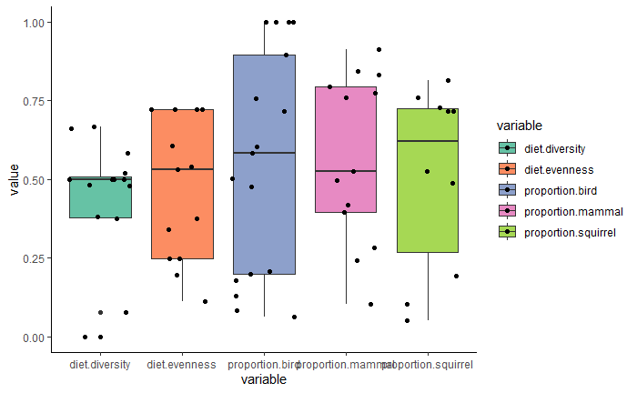

#### **Who else has used these diet quantification methods?**

Lewis et al (2006) used a modified form of the Simpson’s index and standardized the value to account for different numbers of prey categories between sites. Miller et al (2014) used an inverse Simpson’s diversity index using only items identified to genus or species.

Miller et al (2014) used proportion of biomass that was mammalian out of total biomass. Lewis et al (2006) went a slightly different route and used the number of items that were birds or mammals.

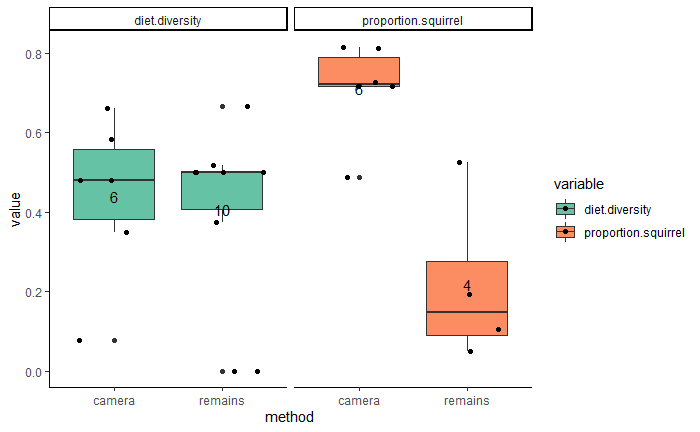

So far there doesn’t appear to be a drastic difference in diversity between the two methods, but there is a dramatic difference in proportion of squirrel biomass. But note the small and very different sample sizes and that there is currently almost no overlap between camera and remains-only sites. This wrinkle may iron out later.

Lewis et al (2004) tested for differences between methods using a linear regression to test for differences in counts between prey categories (ie, avian and mammalian) and also used Morisita’s index of similarity to test for differences in prey species.

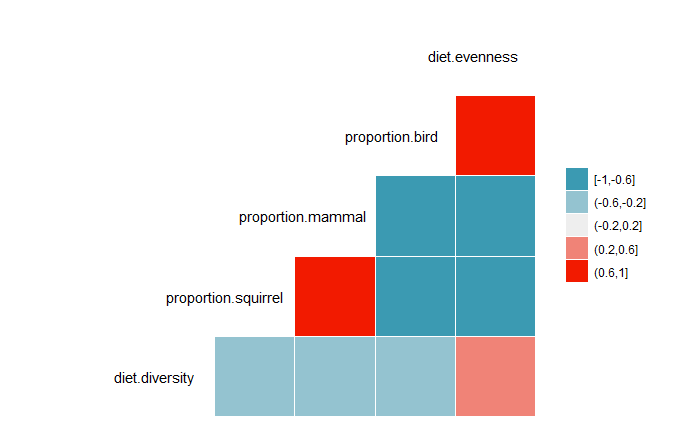

### Productivity

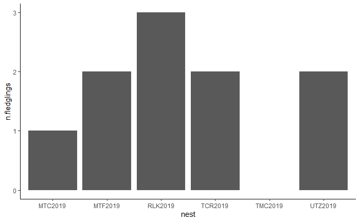

Currently productivity information is only available for the 6 camera sites from 2019. Productivty will (hopefully) be available for the 2020 camera sites as well, making a total of **14 sites** with productivity data.

Miller et al (2014) and Rogers et al (2006) both use productivity with diet. Salafsky et al (2007) uses productivity with prey abundance.

### Occupancy

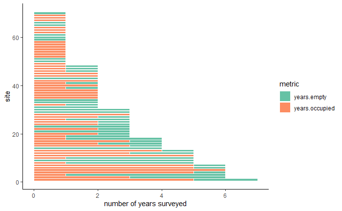

No one seems to have used occupancy as a response variable for diet. Finn et al (2002) does use occupancy as a response for landscape, but classifies sites binomially as occupied or unoccupied. Due to the nature of my data, almost all sites are, by default, “occupied” under Finn’s definition. At any rate, their method doesn’t account for differing habitat quality.

**How to actually use occupancy?** Finn’s yes/no classification seems unhelpful. Percent occupied (n years occupied/n years surveyed) seems to give too much weight to sites with only one years of surveys. **Maybe percent occupied given at least some number of surveys?**

# Predictor variables

| Metric | Variable Forest type | Variable Landcover | Variable Habitat suitability |
| --- | --- | --- | --- |
| **Core area** |  |  |  |
| mean core area |  | x | x |
| proportion core area (mature forest) |  | x |  |
| proportion core area (suitable habitat) |  |  | x |
| **Area and edge** |  |  |  |
| edge density |  | x | x |
| edge density (suitable habitat) |  |  | x |
| edge density (shrub and regen) |  | x |  |
| proportion of landscape in class |  | x | x |
| dominant class | x |  |  |
| mean patch size |  | x | x |
| **Aggregation** |  |  |  |
| cohesion (suitable habitat) |  |  | x |
| cohesion (mature forest) |  | x |  |
| mean nearest neighbor |  | x | x |
| mean nearest neighbor (suitable habitat) |  |  | x |
| mean nearest neighbor (mature forest) |  | x |  |
| patch density |  | x | x |
| contagion | x | x | x |
| interspersion and juxtaposition index | x | x | x |
| **Diversity** |  |  |  |
| patch richness density | x | x | x |
| Simpson's diversity index | x | x | x |
| Simpson's evenness index | x | x | x |

### Forest type

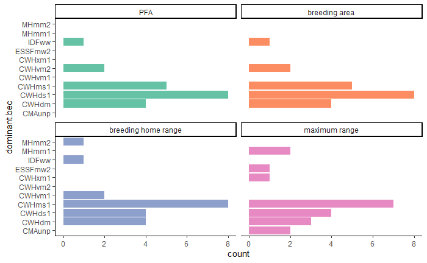

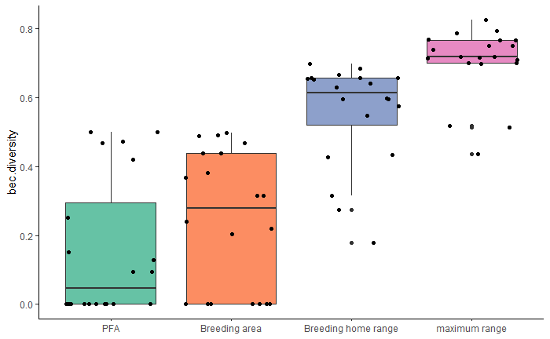

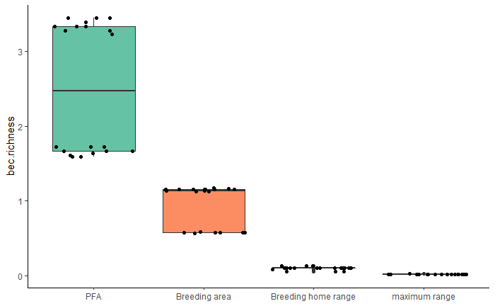

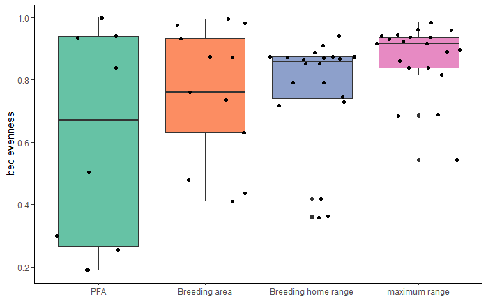

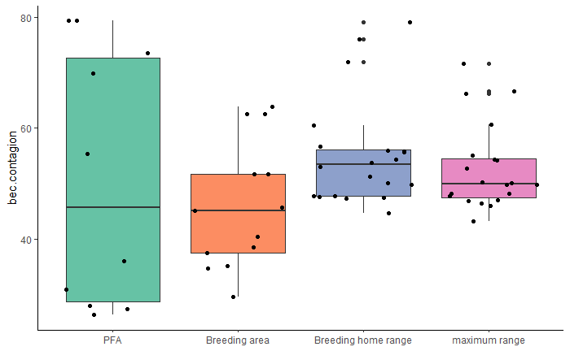

#### **Where do these numbers come from?**

Dominant forest type is simply the forest type with the greatest area at each given scale. Forest type diversity is calculated using Simpson’s diversity index. Forest type richness is just the number of different forest types present at each scale, relative to the scale area. (*there is obviously something very wrong with the richness data*). This is calculated for all sites from both methods **(N = 20)** so the number of sites will increase as I finish processing remains.

#### **Who else has used these landscape variables?**

None, kind of. Lewis et al (2006) compared diet between “habitat types” (hemlock- vs spruce-dominated stands). Salafsky et al (2007) examines goshawk productivity and prey abundance between “forest types” (mixed conifer vs ponderosa pine). These are all based strictly on what forest type the nest is located in, not the overall type present in the landscape. None have used diversity or richness of forest types.

**Would it simplify things to collapse dominant forest types into a few categories?** (ie, western hemlock/mountain hemlock/douglas fir or maybe something weird like dry/moist/ver moist or maritime/submaritime.) **And does it really make sense to consider dominant forest type at different scales?** Again, would it simplify things to only consider the forest type of the nest stand?

### Landcover

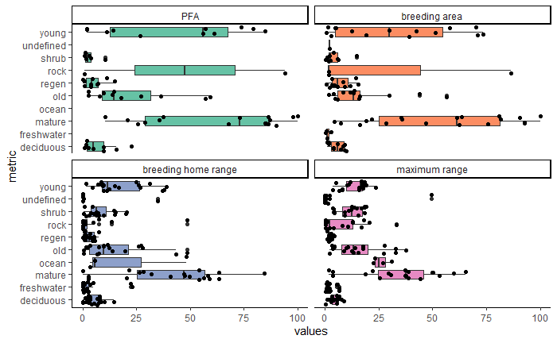

I won’t be using the amount of any particular class, but this visualizes what the classes are and how they’re distributed. There are two additional classes that are present in the landcover data but aren’t present in any of the current sites: alpine and wetland. This is calculated using all the sites with diet data so far (**n = 20 nests**).

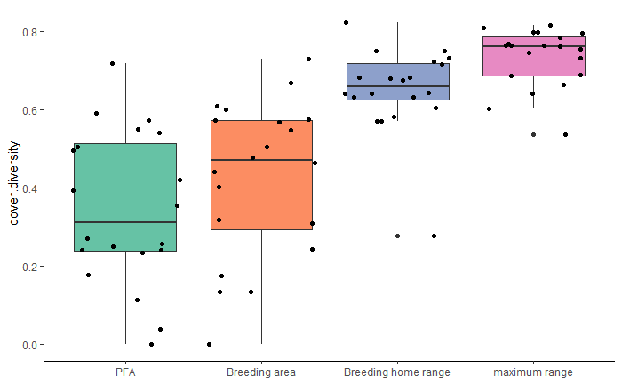

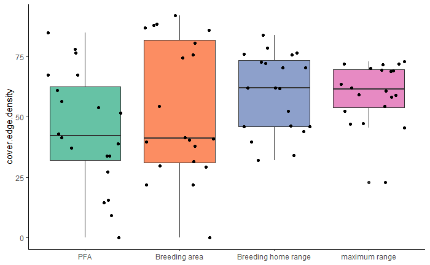

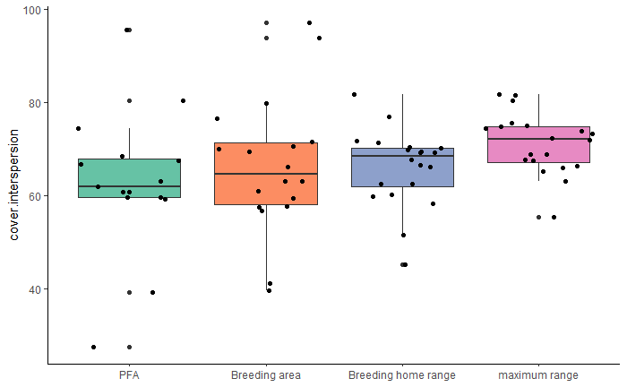

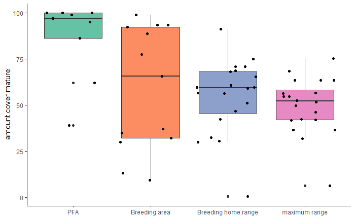

#### **Where do these numbers come from?**

Diversity of landcover classes is calculated using Simpson’s diversity index. Edge density is just edge density (all edges/landscape area * 1000) (so it’s directly comparable between different sizes). Interspersion is the interspersion and juxtaposition index, which is not as sensitive to fragmentation as the contagion index. (**IJI requires at least 3 classes to calculate, which is not always possible at the smaller landscape scales. I converted these missing values to 0, which may be very, very wrong.**) Amount of mature cover is the area of land covered by mature and old growth conifer forest. (**Should this be scaled by making it proportion of land covered by mature forest?**)

#### **Who else has used these landscape metrics?**

Finn et al (2002) used proportion of all landcover classes, along with patch size, patch density, core size, edge density, patch shape, patch richness, dominance index, and contrast. That’s a lot of things. McGrath et al (2003) used contrast-weighted edge density (for structural stage), contrast-weighted edge density (for canopy cover), mean nearest neighbor, Simpson’s evenness (which would be equivalent to Finn et al’s dominance index), and contagion.

Lots more NOGO landscape studies but I haven’t had a chance to add them here. NSPOW would also be a useful comparison.

**Canopy cover may also be included but until I have my complete site set I can’t determine whether I have sufficient data coverage to include it.**

### Habitat suitability index

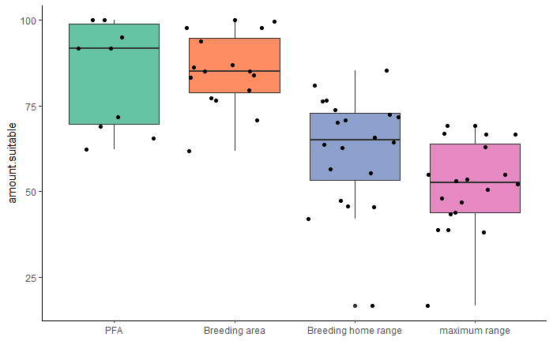

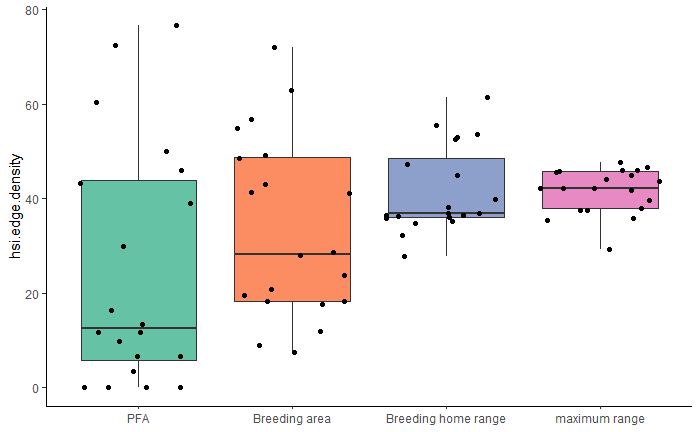

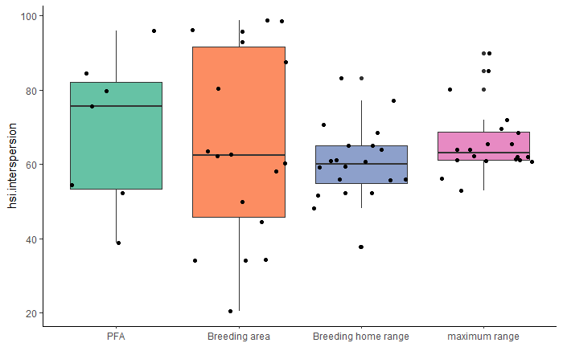

#### **Where do these numbers come from?**

Amount suitable habitat is the area of land considered to be “moderate” or “high” quality habitat. (**Again, should this be scaled as proportion?**) Edge density is edge density, interspersion is the interspersion and juxtaposition index just as for landcover (**with the same sketchy decision to make NAs 0s**). HSI metrics are calculate with the full site set, which is **n = 20 + unprocessed remains sites**.

#### **Who else has used these landscape metrics?**

These are really just the same as are being used for landcover classes. Amount suitable habitat has been used in BC with this particular model for model validation-y things. There’s probably more useful ideas from looking at other modelling studies rather than treating this so much like landcover.

### Geographic position

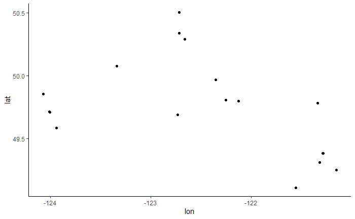

Most NOGO studies have been over too small an area to incorporate lat/lon and this is probably too small an area, too. But some NSPOW papers (Zabel et al 1995? and others?) have noted a difference in diet over latitude. Longitude in this case is a coarse measure of “interiorness” which may be better captured by a different variable.

**Transition zone/coastal zone may do much better as a measure of “interiorness”/“coastalness” but I need to check on definitions/mapping because those are currently a bit unclear.**

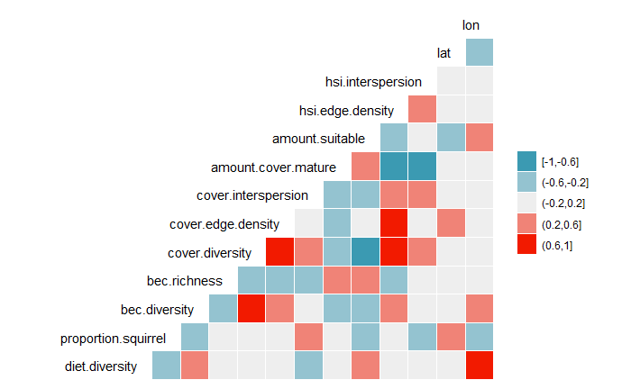

This plot show correlation for all landscape sizes (**should it be for just one of them? The largest?**).

# Models

### Diet diversity models

- diet diversity ~ forest type diversity
- diet diversity ~ forest type richness
- diet diversity ~ dominant forest type
- diet diversity ~ land cover diversity
- diet diversity ~ land cover interspersion
- diet diversity ~ land cover edge density
- diet diversity ~ HSI edge density
- diet diversity ~ HSI interspersion
- diet diversity ~ year (null)

Not modeled:

- ~ amount mature forest
- ~ amound suitable habitat
- ~ geographic position (lat/lon)

Diet diversity ~ forest type diversity

| size | r.squared | adj.r.squared | sigma | statistic | p.value | df |
| --- | --- | --- | --- | --- | --- | --- |
| breeding area | 0.25933924 | 0.17704360 | 0.1443850 | 3.1513120 | 0.10960472 | 2 |
| breeding home range | 0.30275388 | 0.22528209 | 0.1400894 | 3.9079242 | 0.07946186 | 2 |
| maximum range | 0.47106466 | 0.41229407 | 0.1220151 | 8.0153124 | 0.01968598 | 2 |
| PFA | 0.06594668 | -0.03783702 | 0.1621430 | 0.6354242 | 0.44589194 | 2 |

Diet diversity ~ forest type richness

| size | r.squared | adj.r.squared | sigma | statistic | p.value | df |
| --- | --- | --- | --- | --- | --- | --- |
| breeding area | 0.2761558 | 0.1957287 | 0.1427364 | 3.433616 | 0.09688701 | 2 |
| breeding home range | 0.4591820 | 0.3990911 | 0.1233780 | 7.641458 | 0.02195654 | 2 |
| maximum range | 0.3999117 | 0.3332353 | 0.1299630 | 5.997794 | 0.03681469 | 2 |
| PFA | 0.2083716 | 0.1204128 | 0.1492702 | 2.368970 | 0.15815239 | 2 |

Diet diversity ~ dominant forest type

| size | term | estimate | std.error | statistic | p.value |
| --- | --- | --- | --- | --- | --- |
| breeding area | (Intercept) | 0.2976593 | 0.11280050 | 2.6388116 | 0.038601754 |
| breeding area | dominant.becCWHds1 | 0.2095113 | 0.13815183 | 1.5165293 | 0.180173479 |
| breeding area | dominant.becCWHms1 | 0.2843953 | 0.14562482 | 1.9529318 | 0.098657149 |
| breeding area | dominant.becCWHvm2 | 0.2023407 | 0.19537619 | 1.0356469 | 0.340291572 |
| breeding area | dominant.becIDFww | 0.1837248 | 0.19537619 | 0.9403644 | 0.383329764 |
| breeding home range | (Intercept) | 0.2976593 | 0.10611733 | 2.8050014 | 0.030959287 |
| breeding home range | dominant.becCWHds1 | 0.1430980 | 0.15007257 | 0.9535256 | 0.377142413 |
| breeding home range | dominant.becCWHms1 | 0.2810070 | 0.12555972 | 2.2380349 | 0.066526601 |
| breeding home range | dominant.becCWHvm1 | 0.2023407 | 0.18380060 | 1.1008709 | 0.313145836 |
| breeding home range | dominant.becIDFww | 0.1837248 | 0.18380060 | 0.9995877 | 0.356101725 |

[output cut: 12 more lines]

Diet diversity ~ landcover diversity

| size | r.squared | adj.r.squared | sigma | statistic | p.value | df |
| --- | --- | --- | --- | --- | --- | --- |
| breeding area | 0.005745942 | -0.10472673 | 0.1672865 | 0.05201233 | 0.8246951 | 2 |
| breeding home range | 0.029471476 | -0.07836503 | 0.1652785 | 0.27329777 | 0.6137524 | 2 |
| maximum range | 0.126139276 | 0.02904364 | 0.1568315 | 1.29912405 | 0.2837981 | 2 |
| PFA | 0.031734058 | -0.07585105 | 0.1650858 | 0.29496703 | 0.6002454 | 2 |

Diet diversity ~ landcover edge density

| size | r.squared | adj.r.squared | sigma | statistic | p.value | df |
| --- | --- | --- | --- | --- | --- | --- |
| breeding area | 0.001241639 | -0.10973151 | 0.1676650 | 0.01118864 | 0.9180799 | 2 |
| breeding home range | 0.026004708 | -0.08221699 | 0.1655735 | 0.24029107 | 0.6357240 | 2 |
| maximum range | 0.129739768 | 0.03304419 | 0.1565081 | 1.34173420 | 0.2765406 | 2 |
| PFA | 0.007840989 | -0.10239890 | 0.1671102 | 0.07112660 | 0.7957134 | 2 |

Diet diversity ~ landcover interspersion

| size | r.squared | adj.r.squared | sigma | statistic | p.value | df |
| --- | --- | --- | --- | --- | --- | --- |
| breeding area | 0.1466156 | 0.02470357 | 0.1713736 | 1.202634 | 0.3090831 | 2 |
| breeding home range | 0.1322767 | 0.03586302 | 0.1562798 | 1.371970 | 0.2715493 | 2 |
| maximum range | 0.1470674 | 0.05229712 | 0.1549422 | 1.551830 | 0.2443182 | 2 |
| PFA | 0.2300051 | 0.07600608 | 0.1742919 | 1.493549 | 0.2761321 | 2 |

[output not shown]

| size | r.squared | adj.r.squared | sigma | statistic | p.value | df |
| --- | --- | --- | --- | --- | --- | --- |
| breeding area | 0.1669309 | 0.047921002 | 0.0880286 | 1.4026641 | 0.27492798 | 2 |
| breeding home range | 0.2779550 | 0.197727789 | 0.1425589 | 3.4645973 | 0.09560866 | 2 |
| maximum range | 0.1036869 | 0.004096531 | 0.1588335 | 1.0411338 | 0.33420120 | 2 |
| PFA | 0.2124367 | -0.575126666 | 0.1280449 | 0.2697392 | 0.69504724 | 2 |

Diet diversity ~ year (null)

| size | r.squared | adj.r.squared | sigma | statistic | p.value | df |
| --- | --- | --- | --- | --- | --- | --- |
| breeding area | 0 | 0 | 0.1591599 | NA | NA | 1 |
| breeding home range | 0 | 0 | 0.1591599 | NA | NA | 1 |
| maximum range | 0 | 0 | 0.1591599 | NA | NA | 1 |
| PFA | 0 | 0 | 0.1591599 | NA | NA | 1 |

|  | Modnames | K | AICc | Delta_AICc | ModelLik | AICcWt | LL | Cum.Wt |
| --- | --- | --- | --- | --- | --- | --- | --- | --- |
| 28 | ~ HSI interspersion: PFA | 3 | -25.1144536 | 0.00000 | 1.000000e+00 | 9.988522e-01 | 3.557227 | 0.9988522 |
| 25 | ~ HSI interspersion: breeding area | 3 | -9.6626189 | 15.45183 | 4.412419e-04 | 4.407354e-04 | 10.231309 | 0.9992930 |
| 3 | ~ forest type diversity maximum range | 3 | -7.8415876 | 17.27287 | 1.775190e-04 | 1.773152e-04 | 8.635080 | 0.9994703 |
| 6 | ~ forest type richness: breeding home range | 3 | -7.5972049 | 17.51725 | 1.571006e-04 | 1.569203e-04 | 8.512888 | 0.9996272 |
| 7 | ~ forest type richness: maximum range | 3 | -6.4532716 | 18.66118 | 8.866982e-05 | 8.856804e-05 | 7.940922 | 0.9997158 |
| 2 | ~ forest type diversity breeding home range | 3 | -4.8025927 | 20.31186 | 3.884503e-05 | 3.880044e-05 | 7.115582 | 0.9997546 |
| 26 | ~ HSI interspersion: breeding home range | 3 | -4.4181538 | 20.69630 | 3.205203e-05 | 3.201524e-05 | 6.923363 | 0.9997866 |
| 5 | ~ forest type richness: breeding area | 3 | -4.3907785 | 20.72368 | 3.161631e-05 | 3.158002e-05 | 6.909675 | 0.9998182 |
| 1 | ~ forest type diversity breeding area | 3 | -4.1381459 | 20.97631 | 2.786459e-05 | 2.783261e-05 | 6.783359 | 0.9998460 |
| 8 | ~ forest type richness: PFA | 3 | -3.4061021 | 21.70835 | 1.932375e-05 | 1.930157e-05 | 6.417337 | 0.9998653 |

[output cut: 18 more lines]

### Squirrel biomass models

- proportion squirrel ~ dominant forest type
- proportion squirrel ~ landcover diversity
- proportion squirrel ~ landcover edge density
- proportion squirrel ~ landcover interspersion
- proportion squirrel ~ amount mature forest
- proportion squirrel ~ amount suitable habitat
- proportion squirrel ~ HSI edge density
- proportion squirrel ~ HSI interspersion
- proportion squirrel ~ year (null)

Not modeled:

- ~ forest type diversity/richness
- ~ geographic position (lat/lon)

Proportion squirrel ~ dominant forest type

```
Call:
lm(formula = proportion.squirrel ~ dominant.bec, data = data)

Coefficients:
       (Intercept)   dominant.becCWHdm  dominant.becCWHds1  dominant.becCWHms1  dominant.becCWHxm1
           0.76044            -0.06948            -0.22325            -0.28792            -0.23597
 dominant.becIDFww
          -0.04298
```

| size | term | df | sumsq | meansq | statistic | p.value |
| --- | --- | --- | --- | --- | --- | --- |
| breeding area | dominant.bec | 3 | 0.07661606 | 0.02553869 | 0.2807012 | 0.8376609 |
| breeding area | Residuals | 5 | 0.45490870 | 0.09098174 | NA | NA |
| breeding home range | dominant.bec | 3 | 0.15399619 | 0.05133206 | 0.6798435 | 0.6011366 |
| breeding home range | Residuals | 5 | 0.37752856 | 0.07550571 | NA | NA |
| maximum range | dominant.bec | 4 | 0.13896398 | 0.03474099 | 0.3539935 | 0.8306820 |
| maximum range | Residuals | 4 | 0.39256078 | 0.09814020 | NA | NA |
| PFA | dominant.bec | 3 | 0.07661606 | 0.02553869 | 0.2807012 | 0.8376609 |
| PFA | Residuals | 5 | 0.45490870 | 0.09098174 | NA | NA |

Proportion squirrel ~ landcover diversity

| size | r.squared | adj.r.squared | sigma | statistic | p.value | df |
| --- | --- | --- | --- | --- | --- | --- |
| breeding area | 0.093312925 | -0.03621380 | 0.2623865 | 0.72041445 | 0.4240798 | 2 |
| breeding home range | 0.003778873 | -0.13853843 | 0.2750367 | 0.02655245 | 0.8751629 | 2 |
| maximum range | 0.006936455 | -0.13492977 | 0.2746005 | 0.04889434 | 0.8313101 | 2 |
| PFA | 0.085477969 | -0.04516804 | 0.2635177 | 0.65427159 | 0.4452072 | 2 |

Proportion squirrel ~ landcover edge density

| size | r.squared | adj.r.squared | sigma | statistic | p.value | df |
| --- | --- | --- | --- | --- | --- | --- |
| breeding area | 0.01232964 | -0.12876612 | 0.2738538 | 0.08738493 | 0.7761047 | 2 |
| breeding home range | 0.00839007 | -0.13326849 | 0.2743994 | 0.05922741 | 0.8146992 | 2 |
| maximum range | 0.10396677 | -0.02403798 | 0.2608404 | 0.81221028 | 0.3974141 | 2 |
| PFA | 0.04366036 | -0.09295959 | 0.2694752 | 0.31957529 | 0.5895140 | 2 |

Proportion squirrel ~ landcover interspersion

[output not shown]

Proportion squirrel ~ amount mature cover

| size | r.squared | adj.r.squared | sigma | statistic | p.value | df |
| --- | --- | --- | --- | --- | --- | --- |
| breeding area | 0.3973355925 | 0.096003389 | 0.3453181 | 1.318596511 | 0.3696544 | 2 |
| breeding home range | 0.1289852660 | 0.004554590 | 0.2571731 | 1.036603431 | 0.3425045 | 2 |
| maximum range | 0.1199857623 | -0.005730557 | 0.2584982 | 0.954416758 | 0.3611438 | 2 |
| PFA | 0.0004389053 | -0.999122189 | 0.4758952 | 0.000439098 | 0.9866618 | 2 |

Proportion squirrel ~ amount.suitable

| size | r.squared | adj.r.squared | sigma | statistic | p.value | df |
| --- | --- | --- | --- | --- | --- | --- |
| breeding area | 0.0004049355 | -0.19951408 | 0.2818478 | 0.002025498 | 0.9658450 | 2 |
| breeding home range | 0.0861123397 | -0.04444304 | 0.2634263 | 0.659584765 | 0.4434443 | 2 |
| maximum range | 0.1156723293 | -0.01066020 | 0.2591310 | 0.915617968 | 0.3705002 | 2 |
| PFA | 0.0002459990 | -0.49963100 | 0.3503405 | 0.000492119 | 0.9843156 | 2 |

Proportion squirrel ~ HSI edge density

| size | r.squared | adj.r.squared | sigma | statistic | p.value | df |
| --- | --- | --- | --- | --- | --- | --- |
| breeding area | 0.006464293 | -0.13546938 | 0.2746657 | 0.04554446 | 0.8370885 | 2 |
| breeding home range | 0.022389562 | -0.11726907 | 0.2724555 | 0.16031634 | 0.7008037 | 2 |
| maximum range | 0.081919530 | -0.04923482 | 0.2640299 | 0.62460397 | 0.4552772 | 2 |
| PFA | 0.017158284 | -0.12324768 | 0.2731835 | 0.12220481 | 0.7369363 | 2 |

Proportion squirrel ~ HSI interspersion

| size | r.squared | adj.r.squared | sigma | statistic | p.value | df |
| --- | --- | --- | --- | --- | --- | --- |
| breeding area | 0.35441618 | 0.22529941 | 0.2428116 | 2.7449277 | 0.1584642 | 2 |
| breeding home range | 0.03231654 | -0.10592395 | 0.2710687 | 0.2337705 | 0.6434992 | 2 |
| maximum range | 0.04339919 | -0.09325807 | 0.2695120 | 0.3175769 | 0.5906548 | 2 |
| PFA | 1.00000000 | NaN | NaN | NaN | NaN | 2 |

AIC

|  | Modnames | K | AICc | Delta_AICc | ModelLik | AICcWt | LL | Cum.Wt |
| --- | --- | --- | --- | --- | --- | --- | --- | --- |
| 1 | ~ landcover diversity: breeding area | 3 | 9.996202 | Inf | 0 | NaN | 0.4018991134 | NaN |
| 2 | ~ landcover diversity: breeding home range | 3 | 10.843749 | Inf | 0 | NaN | -0.0218742953 | NaN |
| 3 | ~ landcover diversity: maximum range | 3 | 10.815177 | Inf | 0 | NaN | -0.0075886225 | NaN |
| 4 | ~ landcover diversity: PFA | 3 | 10.073639 | Inf | 0 | NaN | 0.3631803107 | NaN |
| 5 | ~ landcover edge density: breeding area | 3 | 10.766166 | Inf | 0 | NaN | 0.0169168451 | NaN |
| 6 | ~ landcover edge density: breeding home range | 3 | 10.801994 | Inf | 0 | NaN | -0.0009968433 | NaN |
| 7 | ~ landcover edge density: maximum range | 3 | 9.889823 | Inf | 0 | NaN | 0.4550885815 | NaN |
| 8 | ~ landcover edge density: PFA | 3 | 10.476043 | Inf | 0 | NaN | 0.1619782753 | NaN |
| 9 | ~ landcover interspersion: breeding area | 3 | 14.500627 | Inf | 0 | NaN | -0.2503132983 | NaN |
| 10 | ~ landcover interspersion: breeding home range | 3 | 10.700069 | Inf | 0 | NaN | 0.0499652972 | NaN |

[output cut: 18 more lines]

### Productivity models

- productivity ~ diet diversity
- productivity ~ proportion squirrel
- productivity ~ amount suitable habitat
- productivity ~ geographic position
- productivity ~ year (null)

Productivity ~ diet diversity

| size | r.squared | adj.r.squared | sigma | statistic | p.value | df |
| --- | --- | --- | --- | --- | --- | --- |
| breeding area | 0.4204273 | 0.2755341 | 0.8790697 | 2.901637 | 0.1636978 | 2 |
| breeding home range | 0.4204273 | 0.2755341 | 0.8790697 | 2.901637 | 0.1636978 | 2 |
| maximum range | 0.4204273 | 0.2755341 | 0.8790697 | 2.901637 | 0.1636978 | 2 |
| PFA | 0.4204273 | 0.2755341 | 0.8790697 | 2.901637 | 0.1636978 | 2 |

Productivity ~ proportion squirrel

| size | r.squared | adj.r.squared | sigma | statistic | p.value | df |
| --- | --- | --- | --- | --- | --- | --- |
| breeding area | 0.8365788 | 0.7957235 | 0.4667922 | 20.47662 | 0.01061685 | 2 |
| breeding home range | 0.8365788 | 0.7957235 | 0.4667922 | 20.47662 | 0.01061685 | 2 |
| maximum range | 0.8365788 | 0.7957235 | 0.4667922 | 20.47662 | 0.01061685 | 2 |
| PFA | 0.8365788 | 0.7957235 | 0.4667922 | 20.47662 | 0.01061685 | 2 |

Productivity ~ amount suitable habitat

| size | r.squared | adj.r.squared | sigma | statistic | p.value | df |
| --- | --- | --- | --- | --- | --- | --- |
| breeding area | 0.02060376 | -0.46909436 | 1.160461 | 0.0420744 | 0.8564599 | 2 |
| breeding home range | 0.13844819 | -0.07693976 | 1.071791 | 0.6427852 | 0.4676279 | 2 |
| maximum range | 0.08738980 | -0.14076275 | 1.103093 | 0.3830323 | 0.5694905 | 2 |
| PFA | 0.00000000 | 0.00000000 | NaN | NA | NA | 1 |

Productivity ~ latitude

| size | r.squared | adj.r.squared | sigma | statistic | p.value | df |
| --- | --- | --- | --- | --- | --- | --- |
| breeding area | 0.01505502 | -0.2311812 | 1.145976 | 0.06114057 | 0.8168752 | 2 |
| breeding home range | 0.01505502 | -0.2311812 | 1.145976 | 0.06114057 | 0.8168752 | 2 |
| maximum range | 0.01505502 | -0.2311812 | 1.145976 | 0.06114057 | 0.8168752 | 2 |
| PFA | 0.01505502 | -0.2311812 | 1.145976 | 0.06114057 | 0.8168752 | 2 |

Productivity ~ longitude

| size | r.squared | adj.r.squared | sigma | statistic | p.value | df |
| --- | --- | --- | --- | --- | --- | --- |
| breeding area | 0.3678853 | 0.2098566 | 0.9180521 | 2.327965 | 0.2017645 | 2 |
| breeding home range | 0.3678853 | 0.2098566 | 0.9180521 | 2.327965 | 0.2017645 | 2 |
| maximum range | 0.3678853 | 0.2098566 | 0.9180521 | 2.327965 | 0.2017645 | 2 |
| PFA | 0.3678853 | 0.2098566 | 0.9180521 | 2.327965 | 0.2017645 | 2 |

Productivity ~ lat & lon

| size | r.squared | adj.r.squared | sigma | statistic | p.value | df |
| --- | --- | --- | --- | --- | --- | --- |
| breeding area | 0.7473268 | 0.3683171 | 0.8208502 | 1.971788 | 0.3539504 | 4 |
| breeding home range | 0.7473268 | 0.3683171 | 0.8208502 | 1.971788 | 0.3539504 | 4 |
| maximum range | 0.7473268 | 0.3683171 | 0.8208502 | 1.971788 | 0.3539504 | 4 |
| PFA | 0.7473268 | 0.3683171 | 0.8208502 | 1.971788 | 0.3539504 | 4 |

|  | Modnames | K | AICc | Delta_AICc | ModelLik | AICcWt | LL | Cum.Wt |
| --- | --- | --- | --- | --- | --- | --- | --- | --- |
| 1 | ~ diet diversity: breeding area | 3 | 31.04778 | Inf | 0 | NaN | -6.523889 | NaN |
| 2 | ~ diet diversity: breeding home range | 3 | 31.04778 | Inf | 0 | NaN | -6.523889 | NaN |
| 3 | ~ diet diversity: maximum range | 3 | 31.04778 | Inf | 0 | NaN | -6.523889 | NaN |
| 4 | ~ diet diversity: PFA | 3 | 31.04778 | Inf | 0 | NaN | -6.523889 | NaN |
| 5 | ~ proportion squirrel: breeding area | 3 | 23.45202 | Inf | 0 | NaN | -2.726010 | NaN |
| 6 | ~ proportion squirrel: breeding home range | 3 | 23.45202 | Inf | 0 | NaN | -2.726010 | NaN |
| 7 | ~ proportion squirrel: maximum range | 3 | 23.45202 | Inf | 0 | NaN | -2.726010 | NaN |
| 8 | ~ proportion squirrel: PFA | 3 | 23.45202 | Inf | 0 | NaN | -2.726010 | NaN |
| 9 | ~ amount suitable habitat: breeding area | 3 | Inf | Inf | 0 | NaN | -4.884729 | NaN |
| 10 | ~ amount suitable habitat: breeding home range | 3 | 33.42644 | Inf | 0 | NaN | -7.713222 | NaN |

[output cut: 14 more lines]